# Formatting stuff

```python
#housekeeping and essential imports
import pandas as pd
import os

pd.set_option('display.max_rows', 500)
pd.set_option('display.width', 1800)
pd.set_option ('display.max_colwidth', 150)
pd.set_option('display.max_columns', 50)

from IPython.core.interactiveshell import InteractiveShell
InteractiveShell.ast_node_interactivity = "all"
```

```python
# surpress warnings
import warnings
warnings.filterwarnings('ignore')
```

```python
from IPython.core.display import display, HTML
display(HTML("<style>.container { width:99% !important; }</style>"))
```

```python
%%HTML
<style type="text/css">
table.dataframe td, table.dataframe th {
    border: None#1px dotted lightgrey;
}
```

[output not shown]

```python
screen1 = screen[['ID', 'Gene', 'S1', 'S2', 'S3', 'S4', 'S5', 'S6', 'S7', 'S8', 'Esb', 'PlC']]
```

```python
# categorize "Target" vs. "Non-target"
screen1['Target'] = screen1.Gene.apply(lambda x: "Non-target" if "NonTargeting" in x else "Target")
```

```python
screen1.columns
```

```
Index(['ID', 'Gene', 'S1', 'S2', 'S3', 'S4', 'S5', 'S6', 'S7', 'S8', 'Esb', 'PlC', 'Target'], dtype='object')
```

```python
screen1.head(2)
screen1.tail(2)
```

|  | ID | Gene | S1 | S2 | S3 | S4 | S5 | S6 | S7 | S8 | Esb | PlC | Target |
| --- | --- | --- | --- | --- | --- | --- | --- | --- | --- | --- | --- | --- | --- |
| 0 | GUIDES_sg00000 | AATF | 0.115953 | 0.055720 | 0.409604 | 0.290473 | 0.035751 | 0.531296 | 0.353677 | 0.000011 | 0.136404 | 0.749207 | Target |
| 1 | GUIDES_sg00001 | AATF | 0.023200 | 0.000019 | 0.000018 | 0.000016 | 0.011925 | 0.000012 | 0.000015 | 0.000011 | 0.027292 | 0.306497 | Target |

|  | ID | Gene | S1 | S2 | S3 | S4 | S5 | S6 | S7 | S8 | Esb | PlC | Target |
| --- | --- | --- | --- | --- | --- | --- | --- | --- | --- | --- | --- | --- | --- |
| 19836 | GUIDES_sg19836 | NonTargeting_Human_0999 | 10.747754 | 10.174734 | 10.186248 | 10.198292 | 11.055168 | 8.604506 | 9.379729 | 0.011273 | 8.442558 | 2.369234 | Non-target |
| 19837 | GUIDES_sg19837 | NonTargeting_Human_1000 | 1.472464 | 0.742699 | 1.549322 | 0.693886 | 1.179387 | 0.912434 | 0.215287 | 0.000011 | 1.268441 | 0.501094 | Non-target |

**Categorize GUIDES based on the group "Non-target". Use 10th percentile of the ratio in the Non-target group as threshold to label each guide as "Hit" or "Non-hit"**

- First calcualte needed ratios:
  1. Stem later time point vs. Stem before time point: `S5/S2`
  2. Induced cells vs. stem before time point: `S6/S2`
  3. Induced cells vs. stem later time point: `S6/S5`

```python
screen1['r52'] = screen1.S5 / screen1.S2
screen1['r62'] = screen1.S6 / screen1.S2
screen1['r65'] = screen1.S6 / screen1.S5
screen1['r21'] = screen1.S2 / screen1.S1
screen1['r31'] = screen1.S3 / screen1.S1
screen1['r32'] = screen1.S3 / screen1.S2
screen1['r76'] = screen1.S7 / screen1.S6
screen1['r86'] = screen1.S8 / screen1.S6
screen1['r87'] = screen1.S8 / screen1.S7
```

- Criteria and steps to be selected as hits:
  1. calculate `10th percentile` of previously calculated fold change of the non-target group as `depletion` criteria
  2. label guide RNAs as hit if fold change is less than set threshold

```python
# calculate the required percentile of the non-target group as threshold
rna_cutoffs = screen1[screen1.Target == 'Non-target'][['r52', 'r62','r65','r21','r31','r32','r76']].quantile(0.1)
```

```python
rna_cutoffs = rna_cutoffs.append(screen1[screen1.Target == 'Non-target'][['r86','r87']].quantile(0.9))
```

```python
rna_cutoffs
```

```
r52    0.541493
r62    0.652863
r65    0.669351
r21    0.640477
r31    0.622443
r32    0.657691
r76    0.652912
r86    4.052526
r87    3.914284
dtype: float64
```

```python
# label guide RNAs
screen1['r52flag'] = screen1['r52'].apply(lambda x: 'Hit' if x < rna_cutoffs['r52'] else 'Non-hit') # deplete
screen1['r62flag'] = screen1['r62'].apply(lambda x: 'Hit' if x < rna_cutoffs['r62'] else 'Non-hit') # deplete
screen1['r65flag'] = screen1['r65'].apply(lambda x: 'Hit' if x < rna_cutoffs['r65'] else 'Non-hit') # deplete
screen1['r21flag'] = screen1['r21'].apply(lambda x: 'Hit' if x < rna_cutoffs['r21'] else 'Non-hit') # deplete
screen1['r31flag'] = screen1['r31'].apply(lambda x: 'Hit' if x < rna_cutoffs['r31'] else 'Non-hit') # deplete
screen1['r32flag'] = screen1['r32'].apply(lambda x: 'Hit' if x < rna_cutoffs['r32'] else 'Non-hit') # deplete
screen1['r76flag'] = screen1['r76'].apply(lambda x: 'Hit' if x < rna_cutoffs['r76'] else 'Non-hit') # deplete
screen1['r86flag'] = screen1['r86'].apply(lambda x: 'Hit' if x > rna_cutoffs['r86'] else 'Non-hit') # enrich
screen1['r87flag'] = screen1['r87'].apply(lambda x: 'Hit' if x > rna_cutoffs['r87'] else 'Non-hit') # enrich
```

```python
screen1.head()
```

|  | ID | Gene | S1 | S2 | S3 | S4 | S5 | S6 | S7 | S8 | Esb | PlC | Target | r52 | r62 | r65 | r21 | r31 | r32 | r76 | r86 | r87 | r52flag | r62flag | r65flag | r21flag | r31flag | r32flag | r76flag | … |
| --- | --- | --- | --- | --- | --- | --- | --- | --- | --- | --- | --- | --- | --- | --- | --- | --- | --- | --- | --- | --- | --- | --- | --- | --- | --- | --- | --- | --- | --- | --- |
| 0 | GUIDES_sg00000 | AATF | 0.115953 | 0.055720 | 0.409604 | 0.290473 | 0.035751 | 0.531296 | 0.353677 | 0.000011 | 0.136404 | 0.749207 | Target | 0.641616 | 9.535174 | 14.861184 | 0.480537 | 3.532509 | 7.351170 | 0.665687 | 0.000021 | 0.000032 | Non-hit | Non-hit | Non-hit | Hit | Non-hit | Non-hit | Non-hit | … |
| 1 | GUIDES_sg00001 | AATF | 0.023200 | 0.000019 | 0.000018 | 0.000016 | 0.011925 | 0.000012 | 0.000015 | 0.000011 | 0.027292 | 0.306497 | Target | 641.118118 | 0.618280 | 0.000964 | 0.000802 | 0.000767 | 0.956989 | 1.339130 | 0.982609 | 0.733766 | Non-hit | Hit | Hit | Hit | Hit | Non-hit | Non-hit | … |
| 2 | GUIDES_sg00002 | AATF | 0.000012 | 0.000019 | 0.000018 | 0.000016 | 0.000012 | 0.000012 | 0.000015 | 0.000011 | 0.000014 | 0.000005 | Target | 0.639785 | 0.618280 | 0.966387 | 1.603448 | 1.534483 | 0.956989 | 1.339130 | 0.982609 | 0.733766 | Non-hit | Hit | Non-hit | Non-hit | Non-hit | Non-hit | Non-hit | … |
| 3 | GUIDES_sg00003 | AATF | 0.718847 | 0.984070 | 0.872614 | 0.677750 | 1.834596 | 1.409070 | 0.538196 | 0.000011 | 0.641047 | 0.666503 | Target | 1.864295 | 1.431880 | 0.768054 | 1.368956 | 1.213909 | 0.886741 | 0.381951 | 0.000008 | 0.000021 | Non-hit | Non-hit | Non-hit | Non-hit | Non-hit | Non-hit | Hit | … |
| 4 | GUIDES_sg00004 | AATF | 0.046388 | 0.018586 | 0.000018 | 0.000016 | 0.095315 | 0.057760 | 0.000015 | 0.000011 | 0.095487 | 0.350281 | Target | 5.128441 | 3.107779 | 0.605989 | 0.400654 | 0.000384 | 0.000958 | 0.000267 | 0.000196 | 0.733766 | Non-hit | Non-hit | Hit | Hit | Hit | Hit | Hit | … |

**Get genes that have `targets` and are `hits`**

Criteria:

- gRNA is `Target`
- gRNA satisfis pertinent threshold and labeled as `Hit`

```python
r52depl = screen1[(screen1.Target == 'Target') & (screen1.r52flag == 'Hit')].groupby('Gene')['ID'].count().sort_values(ascending=False) # r52 depleted genes
r62depl = screen1[(screen1.Target == 'Target') & (screen1.r62flag == 'Hit')].groupby('Gene')['ID'].count().sort_values(ascending=False)
r65depl = screen1[(screen1.Target == 'Target') & (screen1.r65flag == 'Hit')].groupby('Gene')['ID'].count().sort_values(ascending=False)
r21depl = screen1[(screen1.Target == 'Target') & (screen1.r21flag == 'Hit')].groupby('Gene')['ID'].count().sort_values(ascending=False)
r31depl = screen1[(screen1.Target == 'Target') & (screen1.r31flag == 'Hit')].groupby('Gene')['ID'].count().sort_values(ascending=False)
r32depl = screen1[(screen1.Target == 'Target') & (screen1.r32flag == 'Hit')].groupby('Gene')['ID'].count().sort_values(ascending=False)
r76depl = screen1[(screen1.Target == 'Target') & (screen1.r76flag == 'Hit')].groupby('Gene')['ID'].count().sort_values(ascending=False)
r86rich = screen1[(screen1.Target == 'Target') & (screen1.r86flag == 'Hit')].groupby('Gene')['ID'].count().sort_values(ascending=False)
r87rich = screen1[(screen1.Target == 'Target') & (screen1.r87flag == 'Hit')].groupby('Gene')['ID'].count().sort_values(ascending=False)
```

```python
# get number of genes (that are both targeting hit genes) having 1,...,10 guide RNAs.
r52HitGeneCount = r52depl.sort_values(ascending=False).reset_index().groupby('ID').size()
r62HitGeneCount = r62depl.sort_values(ascending=False).reset_index().groupby('ID').size()
r65HitGeneCount = r65depl.sort_values(ascending=False).reset_index().groupby('ID').size()
r21HitGeneCount = r21depl.sort_values(ascending=False).reset_index().groupby('ID').size()
r31HitGeneCount = r31depl.sort_values(ascending=False).reset_index().groupby('ID').size()
r32HitGeneCount = r32depl.sort_values(ascending=False).reset_index().groupby('ID').size()
r76HitGeneCount = r76depl.sort_values(ascending=False).reset_index().groupby('ID').size()
r86HitGeneCount = r86rich.sort_values(ascending=False).reset_index().groupby('ID').size()
r87HitGeneCount = r87rich.sort_values(ascending=False).reset_index().groupby('ID').size()
```

```python
HitGeneCount = pd.DataFrame({'r52HitGeneCount':r52HitGeneCount, 'r62HitGeneCount':r62HitGeneCount, 'r65HitGeneCount':r65HitGeneCount, 'r21HitGeneCount':r21HitGeneCount,
                            'r31HitGeneCount':r31HitGeneCount, 'r32HitGeneCount':r32HitGeneCount, 'r76HitGeneCount':r76HitGeneCount, 'r86HitGeneCount':r86HitGeneCount,
                            'r87HitGeneCount':r87HitGeneCount}).reset_index().fillna(0).rename(columns={'ID':'gRNAs'})
```

```python
HitGeneCount
```

|  | gRNAs | r52HitGeneCount | r62HitGeneCount | r65HitGeneCount | r21HitGeneCount | r31HitGeneCount | r32HitGeneCount | r76HitGeneCount | r86HitGeneCount | r87HitGeneCount |
| --- | --- | --- | --- | --- | --- | --- | --- | --- | --- | --- |
| 0 | 1 | 395.0 | 276.0 | 479 | 349.0 | 394.0 | 423.0 | 384.0 | 524.0 | 524.0 |
| 1 | 2 | 530.0 | 425.0 | 546 | 489.0 | 515.0 | 514.0 | 526.0 | 106.0 | 116.0 |
| 2 | 3 | 442.0 | 453.0 | 399 | 460.0 | 455.0 | 432.0 | 484.0 | 17.0 | 15.0 |
| 3 | 4 | 230.0 | 342.0 | 181 | 278.0 | 223.0 | 240.0 | 244.0 | 1.0 | 1.0 |
| 4 | 5 | 80.0 | 195.0 | 49 | 132.0 | 87.0 | 94.0 | 93.0 | 0.0 | 0.0 |
| 5 | 6 | 29.0 | 76.0 | 18 | 38.0 | 27.0 | 20.0 | 21.0 | 0.0 | 0.0 |
| 6 | 7 | 8.0 | 25.0 | 5 | 9.0 | 10.0 | 5.0 | 2.0 | 0.0 | 0.0 |
| 7 | 8 | 0.0 | 7.0 | 2 | 3.0 | 1.0 | 2.0 | 0.0 | 0.0 | 0.0 |
| 8 | 9 | 0.0 | 1.0 | 2 | 1.0 | 0.0 | 1.0 | 0.0 | 0.0 | 0.0 |
| 9 | 10 | 0.0 | 0.0 | 1 | 0.0 | 0.0 | 0.0 | 0.0 | 0.0 | 0.0 |

```python
HitGeneCount.sum()
```

```
gRNAs                55.0
r52HitGeneCount    1714.0
r62HitGeneCount    1800.0
r65HitGeneCount    1682.0
r21HitGeneCount    1759.0
r31HitGeneCount    1712.0
r32HitGeneCount    1731.0
r76HitGeneCount    1754.0
r86HitGeneCount     648.0
r87HitGeneCount     656.0
dtype: float64
```

## Depletions among conditions of `R2`: Early ES (`S2`), Late ES (`S5`), and +DOX (`S6`).

```python
import sys
sys.path.append("/home/me/mypy")
import vennpy
```

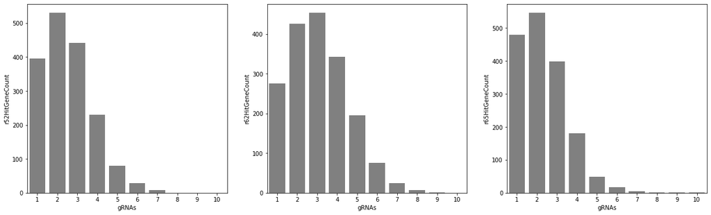

```python
fig, (ax1, ax2, ax3) = plt.subplots(nrows=1, ncols=3, figsize=(21,6))
sns.barplot(x='gRNAs', y='r52HitGeneCount',data=HitGeneCount, ax=ax1, color='grey', )
sns.barplot(x='gRNAs', y='r62HitGeneCount',data=HitGeneCount, ax=ax2, color='grey')
sns.barplot(x='gRNAs', y='r65HitGeneCount',data=HitGeneCount, ax=ax3, color='grey');
```

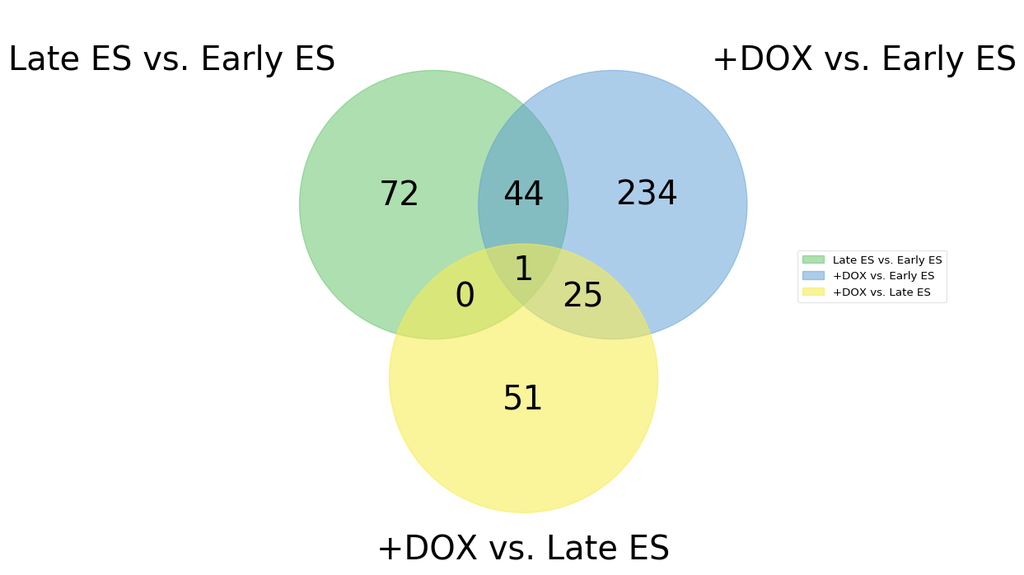

```python
lim = 4 # replicate 2
vennpy.venn3(vennpy.get_labels([set(r52depl[r52depl > lim].index), set(r62depl[r62depl > lim].index), \
                                set(r65depl[r65depl > lim].index)]), names=['Late ES vs. Early ES', '+DOX vs. Early ES', '+DOX vs. Late ES'], fontsize=30);
```

```python
inter_r62_r65 = set(r62depl[r62depl > lim].index).intersection(set(r65depl[r65depl > lim].index)) # set of hit depleted genes between +DOX and two ES conditions
inter_r62_r65_r52 = inter_r62_r65.intersection(set(r52depl[r52depl > lim].index)) # intersect of all three, mark to remove
inter_r62_r65.difference_update(inter_r62_r65_r52) # remove intersect of 3
```

```python
len(inter_r62_r65)
', '.join(inter_r62_r65)
```

```
25
```

```
'DOT1L, POLR2J, BACH2, MYF6, CCRN4L, ING3, TCERG1, ARNTL2, SMARCAD1, PARN, ZNF22, GTF2H2, ZBTB48, CUX1, XRCC3, PLRG1, NEUROD4, RERE, GATAD1, PHF10, DLX2, ZNF615, MCM7, MAZ, RNF2'
```

## Depletions among conditions of `R1`: Early ES (`S1`), Late ES (`S2`), and +DOX (`S3`).

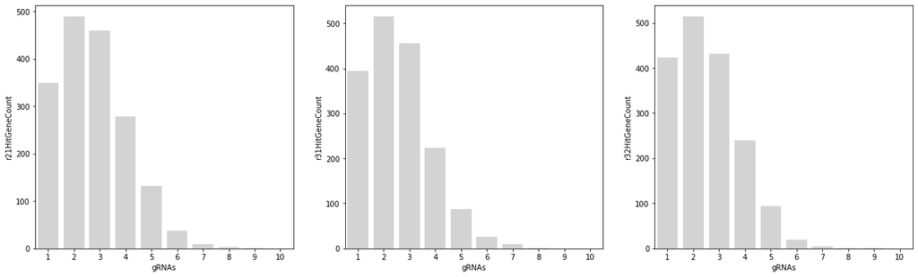

```python
# ploting number of genes per gDNA count group, to help determine threshold for gene sets
fig, (ax1, ax2, ax3) = plt.subplots(nrows=1, ncols=3, figsize=(21,6))
sns.barplot(x='gRNAs', y='r21HitGeneCount',data=HitGeneCount, ax=ax1, color='lightgrey', )
sns.barplot(x='gRNAs', y='r31HitGeneCount',data=HitGeneCount, ax=ax2, color='lightgrey')
sns.barplot(x='gRNAs', y='r32HitGeneCount',data=HitGeneCount, ax=ax3, color='lightgrey');
```

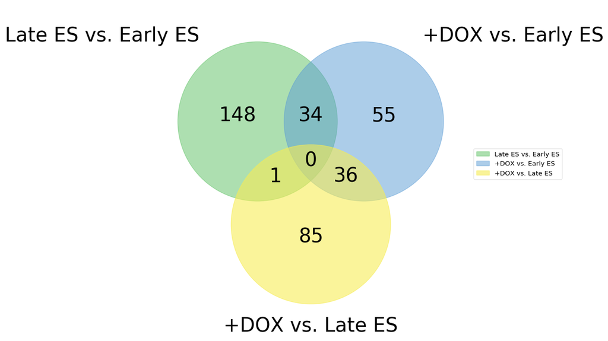

```python
lim2 = 4
vennpy.venn3(vennpy.get_labels([set(r21depl[r21depl > lim2].index), set(r31depl[r31depl > lim2].index), \
                                set(r32depl[r32depl > lim2].index)]), names=['Late ES vs. Early ES', '+DOX vs. Early ES', '+DOX vs. Late ES'], fontsize=30);
```

get set 36 genes

```python
inter_r31_r32 = set(r31depl[r31depl > lim2].index).intersection(set(r32depl[r32depl > lim2].index)) # set of hit depleted genes between +DOX and two ES condition
inter_r31_r32_r21 = inter_r31_r32.intersection(set(r21depl[r21depl > lim2].index)) # intersect of all three, mark to remove
inter_r31_r32.difference_update(inter_r31_r32_r21) # remove intersect of 3
```

```python
len(inter_r31_r32)
", ".join(list(inter_r31_r32))
```

```
36
```

```
'MEN1, DOT1L, SIRT4, PHF20, TCOF1, CALCOCO1, HIST1H2BJ, TCERG1, SMAD4, SMARCAD1, PARN, CREB1, GTF2A2, DAZAP2, SNIP1, SSB, SUGP1, FOXE3, NDNL2, RERE, ZNF148, HES2, ANKRD22, ZNF593, MYBL2, MATR3, ZNF423, ZNF382, HNRNPK, TIGD4, MAZ, CNOT3, NOTCH4, EGR1, PHF23, ASCC3'
```

## Compare the found set of depleted genes in `R1` and `R2`

```python
len(inter_r31_r32)
len(inter_r62_r65)
```

```
36
```

```
25
```

```python
inter_r62_r65.intersection(inter_r31_r32)
```

```
{'DOT1L', 'MAZ', 'PARN', 'RERE', 'SMARCAD1', 'TCERG1'}
```

Get set 6 genese

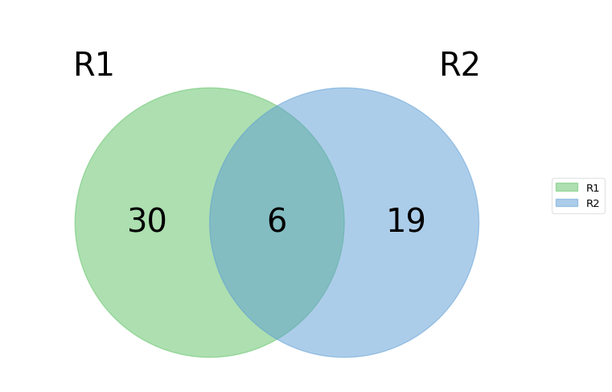

```python
vennpy.venn2(vennpy.get_labels([inter_r31_r32, inter_r62_r65]), names=['R1','R2'], fontsize=30);
```

## Enrichment among tdTomato FACS cells: +DOX (`S6`), tdTomato+ (`S7`), tdTomato- (`S8`)

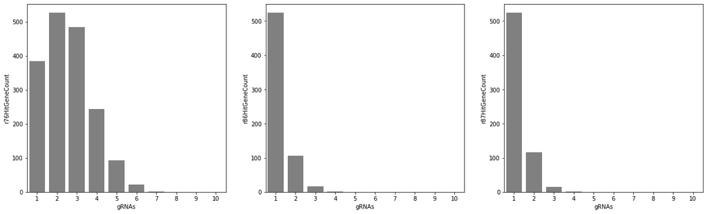

```python
fig, (ax1, ax2, ax3) = plt.subplots(nrows=1, ncols=3, figsize=(21,6))
sns.barplot(x='gRNAs', y='r76HitGeneCount',data=HitGeneCount, ax=ax1, color='grey', )
sns.barplot(x='gRNAs', y='r86HitGeneCount',data=HitGeneCount, ax=ax2, color='grey')
sns.barplot(x='gRNAs', y='r87HitGeneCount',data=HitGeneCount, ax=ax3, color='grey');
```

```python
vennpy.venn3()
```

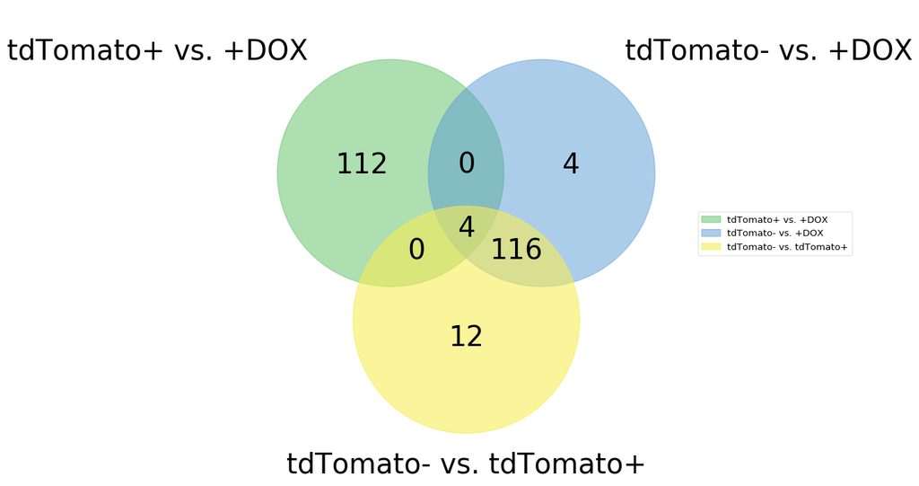

```python
lim31 = 4
lim32 = 1
vennpy.venn3(vennpy.get_labels([set(r76depl[r76depl > lim31].index), set(r86rich[r86rich > lim32].index), \
                                set(r87rich[r87rich > lim32].index)]), names=['tdTomato+ vs. +DOX', 'tdTomato- vs. +DOX', 'tdTomato- vs. tdTomato+'], fontsize=30)
plt.savefig('neville_pdf/fig_3B_venn.pdf', bbox_inches="tight");
```

```python
inter_r86_r87 = set(r87rich[r87rich > lim32].index).intersection(set(r86rich[r86rich > lim32].index)) # set of hit depleted genes between +DOX and two ES condition
```

```python
inter_r86_r87_r76 = inter_r86_r87.intersection(set(r76depl[r76depl > lim31].index)) # intersect of all three, mark to remove
```

```python
', '.join(inter_r86_r87_r76)
```

```
'SMAD3, LHX4, PRDM6, NEUROG3'
```

```python
inter_r86_r87.difference_update(inter_r86_r87_r76)
```

```python
len(inter_r86_r87)
', '.join(inter_r86_r87)
```

```
116
```

```
'SKI, ZFY, ZNF107, ZFPM1, TSHZ3, CEBPA, TCEA2, ZNF554, TAF5, ZKSCAN3, CNOT6, HTATIP2, CDX4, NR1I2, CHD5, NFKBIB, TBPL1, FOXQ1, BHLHA15, ZIC1, MLLT6, PAX7, ZNF547, RCOR2, HIST1H2BC, PAX2, EGR3, ARNTL, TAF1L, SCRT2, NR1D2, DLX5, ZNF141, PHOX2A, NKX3-2, UBE2K, CTDP1, JUND, ZNF239, CREBZF, HSFY1, ZNF92,…
```

```python
drill_list = pd.Series(list(inter_r86_r87) + list(inter_r86_r87_r76))
```

```python
drill_list.to_csv('HS_td-VStd+_td-VSdox120.csv', index=False)
```

```python
!bash pushDropbox.sh
```